# Comparación de paletas de color

Elegir una paleta segura para daltonismo, consistente en todo el libro

Este documento compara la paleta de color que el libro usa **ahora** con tres alternativas **seguras para daltonismo** (*colour-blind-safe*). El objetivo es elegir **una** paleta y aplicarla de forma consistente en todo el libro, incluyendo la versión de 12 colores que necesita el capítulo LTRE.

Cada paleta se muestra simulando **visión normal**, **deuteranopía** (la forma más común, ~6 % de los hombres), **protanopía** y **tritanopía**. Una paleta segura mantiene todos los colores distinguibles en las cuatro filas.

## Paletas de 6 colores

**ACTUAL (libro)**

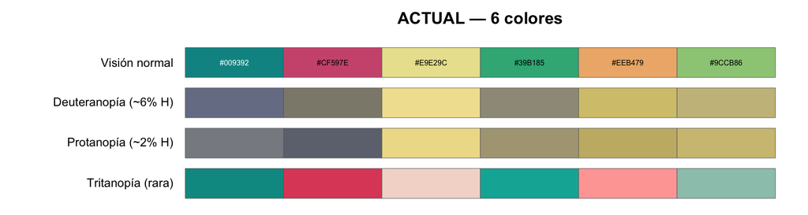

La paleta vigente. Nota: `#E9E29C` (amarillo pálido) tiene muy poco contraste sobre fondo blanco y algunos pares se acercan bajo deuteranopía.

**A. Okabe-Ito**

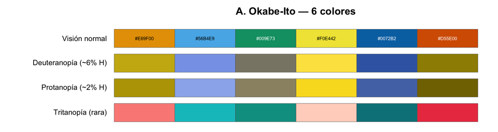

Estándar de facto para paletas cualitativas seguras para daltonismo.

**B. Paul Tol**

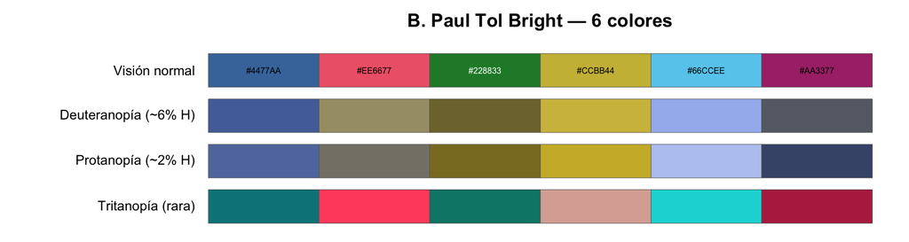

Esquema “Bright”: muy legible, alto contraste.

**C. Viridis**

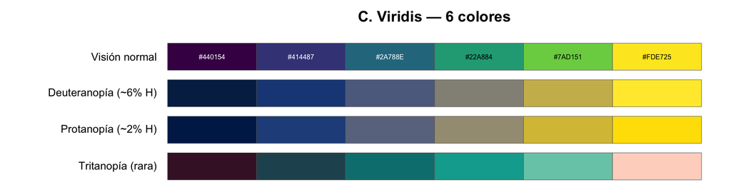

Secuencial: ideal cuando las categorías tienen **orden** (clases de tamaño/etapa).

## Paletas de 12 colores (para LTRE)

**ACTUAL (LTRE)**

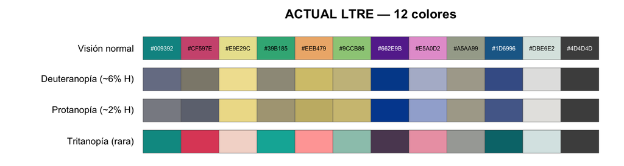

**A. Okabe-Ito (ext.)**

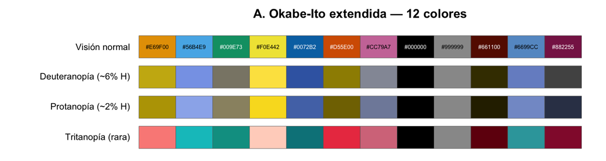

Okabe-Ito solo define 8; se extiende con 4 tonos. Más allá de ~8 categorías nominales, Viridis suele ser la opción más segura.

**B. Paul Tol rainbow**

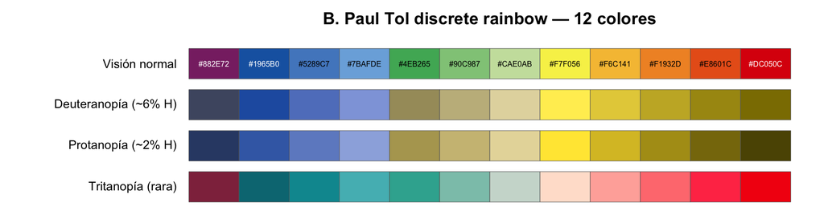

**C. Viridis**

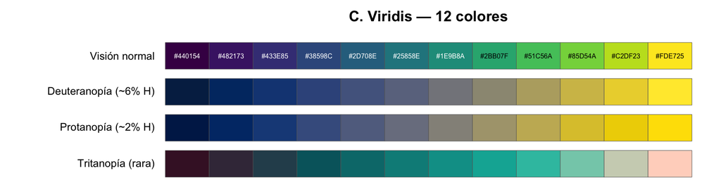

## Ejemplo en un gráfico real

Las mismas paletas aplicadas a un gráfico de barras de 6 categorías (p. ej. clases de etapa), para apreciarlas en contexto.

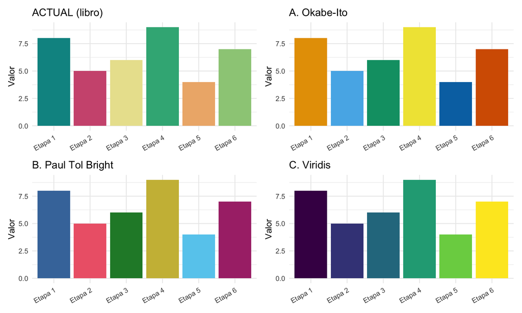

## Tabla de códigos hex

```r
# Paletas de 6
palettes_6
```

```
$`ACTUAL (libro)`
[1] "#009392" "#CF597E" "#E9E29C" "#39B185" "#EEB479" "#9CCB86"

$`A. Okabe-Ito`
[1] "#E69F00" "#56B4E9" "#009E73" "#F0E442" "#0072B2" "#D55E00"

$`B. Paul Tol Bright`
[1] "#4477AA" "#EE6677" "#228833" "#CCBB44" "#66CCEE" "#AA3377"

$`C. Viridis`
[1] "#440154" "#414487" "#2A788E" "#22A884" "#7AD151" "#FDE725"
```

```r
# Paletas de 12
palettes_12
```

```
$`ACTUAL (LTRE)`
 [1] "#009392" "#CF597E" "#E9E29C" "#39B185" "#EEB479" "#9CCB86" "#662E9B"
 [8] "#E5A0D2" "#A5AA99" "#1D6996" "#DBE6E2" "#4D4D4D"

$`A. Okabe-Ito (ext.)`
 [1] "#E69F00" "#56B4E9" "#009E73" "#F0E442" "#0072B2" "#D55E00" "#CC79A7"
 [8] "#000000" "#999999" "#661100" "#6699CC" "#882255"

$`B. Paul Tol rainbow`
 [1] "#882E72" "#1965B0" "#5289C7" "#7BAFDE" "#4EB265" "#90C987" "#CAE0AB"
 [8] "#F7F056" "#F6C141" "#F1932D" "#E8601C" "#DC050C"

$`C. Viridis`
 [1] "#440154" "#482173" "#433E85" "#38598C" "#2D708E" "#25858E" "#1E9B8A"
 [8] "#2BB07F" "#51C56A" "#85D54A" "#C2DF23" "#FDE725"
```

**Cuando elija**, dígame cuál (ACTUAL / A / B / C) y la aplico en `R/rlt_theme.R` y en los 7 capítulos con tema inline (108, 110, 112, 114, 115, 118, 122), manteniendo la versión de 12 colores sincronizada para LTRE.